# Individual Project: Modeling with NHL Power Play Data

Arusyak Hakobyan

December 5, 2018

Imagine watching NHL team and they draw a powerplay, we think ice is free with the missing player and it will be easier to score. But how important is this seemingly advantageous situation in the NHL?

## Setup

Loading some useful packages for analysis and plotting:

```r
library(tidyverse)
library(RCurl)
library(broom)
library(gridExtra)
library(knitr)
library(kableExtra)
library(RColorBrewer)
```

```r
data4v5 <- read.csv("nhl_data.csv")
```

Let’s load the data and make sure that entries of the Atlanta Thrashers and the Winnipeg Jets are combined, as the Thrashers moved to Winnipeg after the 2011 season. Thus, the Thrashers and the Jets are considered the same team here.

```r
# Combine ATL and WPG as ATL.WPG
data4v5$Team <- plyr::revalue(data4v5$Team, c(ATL = 'ATL.WPG', WPG = 'ATL.WPG'))
```

For more interpretable regression model coefficents, let us represent the year as a continuous variable. This way an increase of one year is equivalent to one year of hockey played.

```r
data4v5 <- data4v5 %>%
            separate(Season, c('StartYear', 'EndYear'), sep = '-', remove = F) %>%
            mutate_at(c('StartYear', 'EndYear'), funs(as.numeric))
```

Next, we sort teams by NHL team division following the 2013-2014 realignment scheme.

```r
# Initialize variables for storing team names
pacific <- c('S.J', 'CGY', 'L.A', 'ANA', 'EDM', 'VAN', 'ARI')
central <- c('ATL.WPG', 'NSH', 'STL', 'DAL', 'COL', 'MIN', 'CHI')
metropolitan <- c('WSH', 'N.J', 'PHI', 'CBJ', 'PIT', 'NYR', 'NYI', 'CAR')
atlantic <- c('T.B', 'BOS', 'TOR', 'DET', 'MTL', 'FLA', 'OTT', 'BUF')

# Create column for identifying each team's division
data4v5 <- data4v5 %>%
  mutate(division = case_when(data4v5$Team %in% pacific ~ 'Pacific',
                              data4v5$Team %in% central ~ 'Central',
                              data4v5$Team %in% metropolitan ~ 'Metropolitan',
                              data4v5$Team %in% atlantic ~ 'Atlantic'))
```

See the table detailing the 2013 realignment:

```r
# Creates the data frame for html table
divisions <- data.frame(Pacific = c(pacific, ''),
                        Central = c(central, ''),
                        Metropolitan = metropolitan,
                        Atlantic = atlantic)

# Prints table
kable(divisions) %>%
  kable_styling(bootstrap_options = c('striped', 'hover', 'responsive'))
```

| Pacific | Central | Metropolitan | Atlantic |
| --- | --- | --- | --- |
| S.J | ATL.WPG | WSH | T.B |
| CGY | NSH | N.J | BOS |
| L.A | STL | PHI | TOR |
| ANA | DAL | CBJ | DET |
| EDM | COL | PIT | MTL |
| VAN | MIN | NYR | FLA |
| ARI | CHI | NYI | OTT |
|  |  | CAR | BUF |

## Data Exploration

Before going into analysis, let us first explore the data via various graphs. Try to see if the amount of standard 4 vs. 5 regular season power play goals are changing over time across 11 years in the NHL

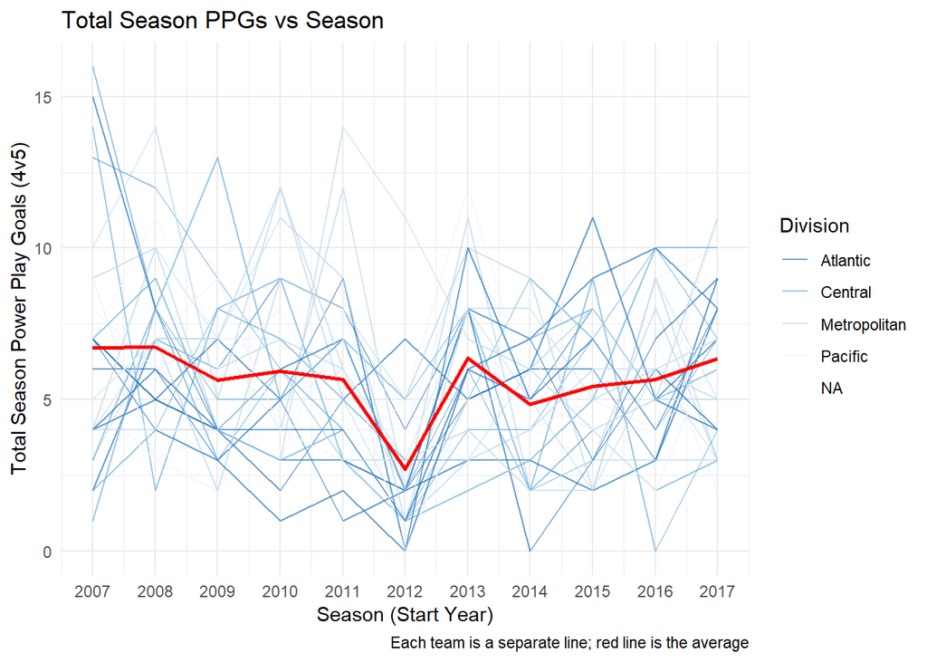

```r
ggplot(data4v5, aes(StartYear, GF, group = 1)) +
  geom_line(aes(group = Team, color = division), alpha = 2/3) +
  geom_line(stat = 'summary', fun.y = 'mean', size = .9, color = 'red') +
  scale_color_brewer(palette = 'Blues', direction = -1) +
  labs(x = 'Season (Start Year)',
       y = 'Total Season Power Play Goals (4v5)',
       caption = 'Each team is a separate line; red line is the average') +
  ggtitle("Total Season PPGs vs Season") +
  guides(color = guide_legend(title = 'Division')) +
  scale_x_continuous(limits = c(2007, 2017), breaks = c(2007:2017)) +
  theme_minimal()
```

The plot shows a dramatic decrease in power play goals during the 2012-2013 season. This is a result of the shortened season, which would greatly reduce the amount of powerplay goal attempts, due to the 2012-2013 NHL lockout.

For controling this shortended season, let us divide the powerplay goals by the amount of games played per season:

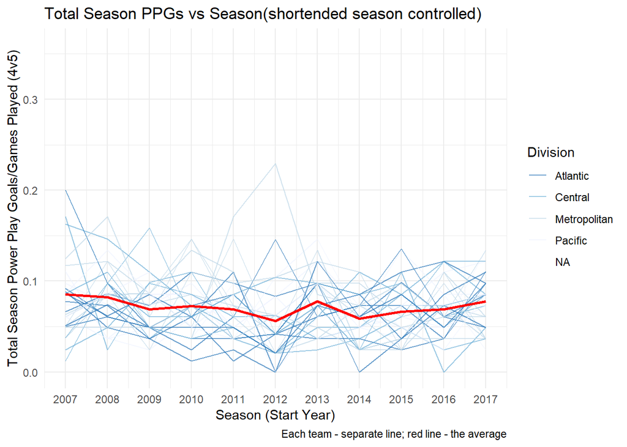

```r
ggplot(data4v5, aes(StartYear, GF/GP, group = 1)) +
  geom_line(aes(group = Team, color = division), alpha = 2/3) +
  geom_line(stat = 'summary', fun.y = 'mean', size = .9, color = 'red') +
  scale_color_brewer(palette = 'Blues', direction = -1) +
  labs(x = 'Season (Start Year)',
       y = 'Total Season Power Play Goals/Games Played (4v5)',
       caption = 'Each team - separate line; red line - the average') +
  ggtitle("Total Season PPGs vs Season(shortended season controlled)") +
  guides(color = guide_legend(title = 'Division')) +
  scale_x_continuous(limits = c(2007, 2017), breaks = c(2007:2017)) +
  theme_minimal()
```

Now having controlled the number of games played per season, we can see that there seems to be a stable average powerplay goals scored per season for each subsequent year of the play.